# Calories Food

Jane Doe

2025-04-10

# Analysis of calories in various food products

Name student: Jane Doe Student number: 123456 Date: 2025-04-10

## Introduction

In today’s society, there’s a widespread awareness regarding food consumption. Quantifying caloric intake and reducing lipid consumption are common recommendations from dietitians and nutritionists. Therefore, knowledge about the nutrient composition of various foods is essential. The dataset analyzed in this report comprises a comma-separated values (CSV) file with data from over 300 food products. For each item, the quantities of calories, lipids, proteins, saturated fatty acids, carbohydrates, and dietary fibers are labeled. Furthermore, the food products are classified into different categories, such as desserts, vegetables, fruits, and so on.

## Dataset

The dataset originates from Kaggle [Kaggle](https://www.kaggle.com/datasets/niharika41298/nutrition-details-for-most-common-foods).  
The dataset uses [Wikipedia](https://en.wikipedia.org/wiki/Table_of_food_nutrients) as a reference.

## Aim

The primary goal of the data analysis of this dataset is to quantify and compare the calorie content between different food groups and within individual food groups. The analysis specifically aims to provide the following insights:

• Identification of the food group(s) with the highest average calorie content. This helps us determine which categories of food generally contribute the most to total energy intake. • Identification of the specific food item within the food group that has the highest average calorie count. This pinpoints individual food items that could significantly contribute to high calorie consumption. • Identification of the item within the entire dataset with the highest number of calories. • Highlighting items with a caloric amount higher than the median.

## Loading libraries

```r
library(tidyverse)
```

## Data Import

First, the data was viewed in Visual Studio Code. A screenshot can be seen below.

[figure not shown]

data

Looking at the file, it’s a CSV file with the comma as the column separator and decimals separated by a period.  
Next, I loaded the file in R via `read_csv`:

```r
folder <- "data"
file_name <- "nutrients_csvfile.csv"
file_path <- paste0("../", folder, "/", file_name) # ../ means one directory higher
df1 <- read_csv(file_path)
head(df1)
```

```
## # A tibble: 6 × 10
##   Food         Measure Grams Calories Protein Fat   Sat.Fat Fiber Carbs Category
##   <chr>        <chr>   <dbl> <chr>    <chr>   <chr> <chr>   <chr> <chr> <chr>
## 1 Cows' milk   1 qt.     976 660      32      40    36      0     48    Dairy p…
## 2 Milk skim    1 qt.     984 360      36      t     t       0     52    Dairy p…
## 3 Buttermilk   1 cup     246 127      9       5     4       0     13    Dairy p…
## 4 Evaporated,… 1 cup     252 345      16      20    18      0     24    Dairy p…
## 5 Fortified m… 6 cups   1419 1,373    89      42    23      1.4   119   Dairy p…
## 6 Powdered mi… 1 cup     103 515      27      28    24      0     39    Dairy p…
```

The ‘Calories’ column is being incorrectly imported as a character data type. This is the same problem as encountered in Excel.

Check for the elements.

```r
head(df1$Calories)
```

```
## [1] "660"   "360"   "127"   "345"   "1,373" "515"
```

```r
df1 %>%
  filter(Calories == "8-44")
```

```
## # A tibble: 1 × 10
##   Food      Measure Grams Calories Protein Fat   Sat.Fat Fiber Carbs Category
##   <chr>     <chr>   <dbl> <chr>    <chr>   <chr> <chr>   <chr> <chr> <chr>
## 1 Artichoke 1 large   100 8-44     2       t     t       2     10    Vegetables…
```

So here too, elements with a range (8-44). Check if there are also blanks present (which have been loaded as NAs):

```r
df1 %>%
  summarise(missing_calories = sum(is.na(Calories)))
```

```
## # A tibble: 1 × 1
##   missing_calories
##              <int>
## 1                1
```

One `NA` value was found to be loaded. This was blank and is read as `NA` by default by `read_csv`.

Identify the item:

```r
df1 %>%
  filter(is.na(Calories))
```

```
## # A tibble: 1 × 10
##   Food        Measure Grams Calories Protein Fat   Sat.Fat Fiber Carbs Category
##   <chr>       <chr>   <dbl> <chr>    <chr>   <chr> <chr>   <chr> <chr> <chr>
## 1 Frozen peas 1 cup     100 <NA>     5       t     0       1.8   12    Vegetabl…
```

Consistent with the Excel analysis: `Frozen Peas`.

## Cleaning

Removing the relevant rows:

```r
df2 <- df1 %>%
  filter(!Calories == "8-44")
```

Check if the row is indeed removed:

```r
df2 %>%
  filter(Calories == "8-44")
```

```
## # A tibble: 0 × 10
## # ℹ 10 variables: Food <chr>, Measure <chr>, Grams <dbl>, Calories <chr>,
## #   Protein <chr>, Fat <chr>, Sat.Fat <chr>, Fiber <chr>, Carbs <chr>,
## #   Category <chr>
```

Correct! The row is removed.

Now, remove the missing value:

```r
df3 <- df2 %>%
  filter(!Food == "Frozen peas")
```

Check if the row is indeed removed:

```r
df3 %>%
  filter(Food == "Frozen peas")
```

```
## # A tibble: 0 × 10
## # ℹ 10 variables: Food <chr>, Measure <chr>, Grams <dbl>, Calories <chr>,
## #   Protein <chr>, Fat <chr>, Sat.Fat <chr>, Fiber <chr>, Carbs <chr>,
## #   Category <chr>
```

Correct! The row is removed.

Now, set the column to the correct data type:

```r
df4 <- df3 %>%
  mutate(Calories = as.numeric(gsub(",", "", Calories))) #gsub will remove the comma's.
head(df4)
```

```
## # A tibble: 6 × 10
##   Food         Measure Grams Calories Protein Fat   Sat.Fat Fiber Carbs Category
##   <chr>        <chr>   <dbl>    <dbl> <chr>   <chr> <chr>   <chr> <chr> <chr>
## 1 Cows' milk   1 qt.     976      660 32      40    36      0     48    Dairy p…
## 2 Milk skim    1 qt.     984      360 36      t     t       0     52    Dairy p…
## 3 Buttermilk   1 cup     246      127 9       5     4       0     13    Dairy p…
## 4 Evaporated,… 1 cup     252      345 16      20    18      0     24    Dairy p…
## 5 Fortified m… 6 cups   1419     1373 89      42    23      1.4   119   Dairy p…
## 6 Powdered mi… 1 cup     103      515 27      28    24      0     39    Dairy p…
```

The `Calories` column is now being read correctly.

## Identification of the food group(s) with the average highest and lowest calorie content

To calculate the averages per category, a new dataframe is created by first grouping all similar category values. Then, the `summarize_each` function is used with the `mean`. Subsequently, the relevant columns are selected.

```r
df5 <- df4 %>%
  group_by(Category) %>%
  select(4) %>%
  summarize_each(funs(mean))
df5
```

```
## # A tibble: 16 × 2
##    Category                         Calories
##    <chr>                               <dbl>
##  1 Breads, cereals, fastfood,grains    265.
##  2 Dairy products                      301.
##  3 Desserts, sweets                    228.
##  4 Drinks,Alcohol, Beverages            92.7
##  5 Fats, Oils, Shortenings             259.
##  6 Fish, Seafood                       153.
##  7 Fruits A-F                          151.
##  8 Fruits G-P                          145.
##  9 Fruits R-Z                          154.
## 10 Jams, Jellies                       168.
## 11 Meat, Poultry                       267.
## 12 Seeds and Nuts                      341.
## 13 Soups                               119.
## 14 Vegetables A-E                       65.9
## 15 Vegetables F-P                       50.8
## 16 Vegetables R-Z                       99.8
```

Or via across (new way to achieve this):

```r
df5 <- df4 %>%
  group_by(Category) %>%
  summarise(across(Calories, mean))
df5
```

```
## # A tibble: 16 × 2
##    Category                         Calories
##    <chr>                               <dbl>
##  1 Breads, cereals, fastfood,grains    265.
##  2 Dairy products                      301.
##  3 Desserts, sweets                    228.
##  4 Drinks,Alcohol, Beverages            92.7
##  5 Fats, Oils, Shortenings             259.
##  6 Fish, Seafood                       153.
##  7 Fruits A-F                          151.
##  8 Fruits G-P                          145.
##  9 Fruits R-Z                          154.
## 10 Jams, Jellies                       168.
## 11 Meat, Poultry                       267.
## 12 Seeds and Nuts                      341.
## 13 Soups                               119.
## 14 Vegetables A-E                       65.9
## 15 Vegetables F-P                       50.8
## 16 Vegetables R-Z                       99.8
```

Now, create a bar plot from this data:

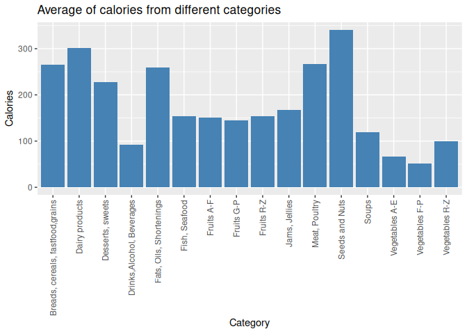

```r
p <- df5 %>% ggplot(aes(x = Category, y = Calories)) +
  geom_bar(stat="identity", fill="steelblue") +
  labs(title="Average of calories from different categories") +
  theme(axis.text.x = element_text(angle = 90, hjust=1, vjust=0.5))
p
```

In this chart, you can see that seeds and nuts have, on average, the highest calorie content, while vegetables have the lowest.

To gain more insight into the data’s distribution, I also created a Boxplot:

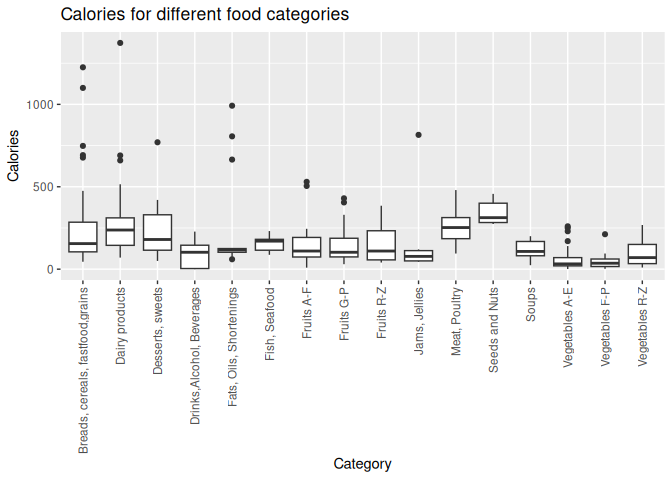

```r
p <- df4 %>%
  ggplot(aes(x = `Category`, y = `Calories`)) +
  geom_boxplot() +
  labs(title="Calories for different food categories") +
  theme(axis.text.x = element_text(angle = 90, hjust=1, vjust=0.5))
p
```

Here too, it’s evident that seeds and nuts rank highest (showing the highest median). Bread and breakfast exhibits a wide spread in its data.

## Identifying the Specific Food Item with the Highest Average Calorie Content

To identify the food items with the highest calorie count within the category that has the highest average, I first filtered for the `Seeds and Nuts` category.

```r
df6 <- df4 %>%
  filter(Category == "Seeds and Nuts")
head(df6)
```

```
## # A tibble: 6 × 10
##   Food         Measure Grams Calories Protein Fat   Sat.Fat Fiber Carbs Category
##   <chr>        <chr>   <dbl>    <dbl> <chr>   <chr> <chr>   <chr> <chr> <chr>
## 1 Almonds      1/2 cup    70      425 13      38    28      1.8   13    Seeds a…
## 2 roasted and… 1/2 cup    70      439 13      40    31      1.8   13    Seeds a…
## 3 Brazil nuts  1/2 cup    70      457 10      47    31      2     7     Seeds a…
## 4 Cashews      1/2 cup    70      392 12      32    28      0.9   20    Seeds a…
## 5 coconut swe… 1/2 cup    50      274 1       20    19      2     26    Seeds a…
## 6 Peanut butt… 1/3 cup    50      300 12      25    17      0.9   9     Seeds a…
```

Subsequently, the bar plot was created:

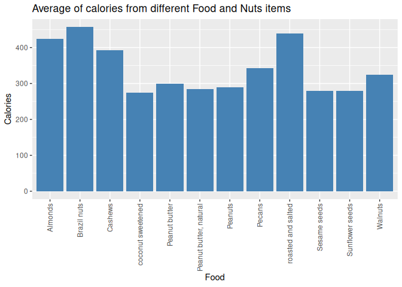

```r
p <- df6 %>%
  ggplot(aes(x = Food, y = Calories)) +
  geom_bar(stat="identity", fill="steelblue") +
  labs(title="Average of calories from different Food and Nuts items") +
  theme(axis.text.x = element_text(angle = 90, hjust=1, vjust=0.5))
p
```

Based on this, Brazil nuts and Roasted and salted can be classified as having the highest calories.

I then also created a pie chart for this analysis:

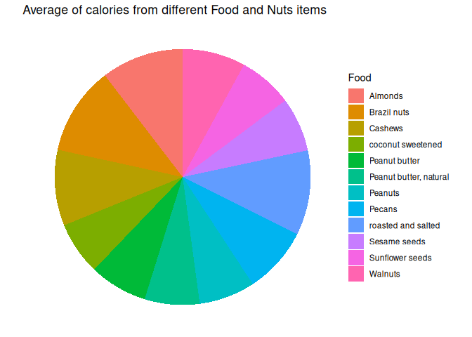

```r
p <- df6 %>%
  ggplot(aes(x = "", y = Calories, fill = Food)) +
  geom_bar(stat="identity", width=1) +
  coord_polar("y", start=0) +
  labs(title="Average of calories from different Food and Nuts items") +
  theme_void() # remove background, grid, numeric labels
p
```

## Identifying the Food Item with the Highest Calorie Content Across the Entire Dataset

Therefore, an analysis was also performed on the absolute highest and lowest values within the entire data set.

The Row with the Highest Value:

```r
df4 %>%
  filter(Calories == max(Calories))
```

```
## # A tibble: 1 × 10
##   Food         Measure Grams Calories Protein Fat   Sat.Fat Fiber Carbs Category
##   <chr>        <chr>   <dbl>    <dbl> <chr>   <chr> <chr>   <chr> <chr> <chr>
## 1 Fortified m… 6 cups   1419     1373 89      42    23      1.4   119   Dairy p…
```

The Row with the Lowest Value:

```r
df4 %>%
  filter(Calories == min(Calories))
```

```
## # A tibble: 2 × 10
##   Food         Measure Grams Calories Protein Fat   Sat.Fat Fiber Carbs Category
##   <chr>        <chr>   <dbl>    <dbl> <chr>   <chr> <chr>   <chr> <chr> <chr>
## 1 Carbonated … 12 oz.    346        0 0       0     0       0     0     Drinks,…
## 2 Club soda    12 oz.    346        0 0       0     0       0     0     Drinks,…
```

## Filtering for items with a higher caloric amount than the median.

To select food items with a high caloric value, I used the median. The median is more robust than the mean and less susceptible to individual outliers. I first calculated the median of the calorie count:

```r
med_val <- df4 %>%
  summarise(med_val = median(Calories, na.rm = TRUE)) %>%
  pull(med_val)
med_val
```

```
## [1] 132
```

The number of rows that are higher than the median:

```r
df4 %>%
  summarise(count_above_median = sum(Calories > med_val))
```

```
## # A tibble: 1 × 1
##   count_above_median
##                <int>
## 1                166
```

Next, I sorted for rows with calories higher than the median, and then sorted those by calories from highest to lowest:

```r
df7 <- df4 %>%
  filter(Calories >  med_val) %>%
  arrange(desc(Calories))
df7
```

```
## # A tibble: 166 × 10
##    Food        Measure Grams Calories Protein Fat   Sat.Fat Fiber Carbs Category
##    <chr>       <chr>   <dbl>    <dbl> <chr>   <chr> <chr>   <chr> <chr> <chr>
##  1 Fortified … 6 cups   1419     1373 89      42    23      1.4   119   Dairy p…
##  2 White, 20 … 1-lb. …   454     1225 39      15    12      9.00  229   Breads,…
##  3 Whole-wheat 1-lb. …   454     1100 48      14    10      67.50 216   Breads,…
##  4 Lard        1/2 cup   110      992 0       110   92      0     0     Fats, O…
##  5 Brown, fir… 1 cup     220      815 0       t     0       0     210   Jams, J…
##  6 Margarine   1/2 cup   112      806 t       91    76      0     t     Fats, O…
##  7 Puddings S… 1 cup     200      770 0       0     0       0     199   Dessert…
##  8 Rice        1 cup     208      748 15      3     0       1.2   154   Breads,…
##  9 White       1 cup     191      692 14      t     0       0.3   150   Breads,…
## 10 (1/2 cup i… 2 cups    540      690 24      24    22      0     70    Dairy p…
## # ℹ 156 more rows
```

## Conclusion and Discussion:

By calculating the median calorie content and applying it for conditional formatting, food items with a relatively high calorie content were visually highlighted in the dataset. These findings underscore the wide range of calories within different food groups and individual products.

The results can be valuable for consumers looking to monitor their calorie intake, as well as for professionals in the food industry and healthcare. The wide spread within some categories, such as bread and cereals, suggests that further, more detailed analyses within these groups could be beneficial.

## Checklist:

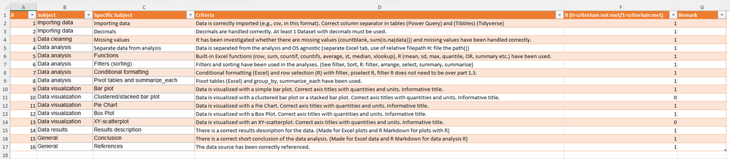

data

It appears that two elements are still missing from the portfolio: • Clustered bar plot • XY scatterplot